# When is the Search for Meaning Related to Life Satisfaction? - Park - 2010 - Applied Psychology: Health and Well-Being - Wiley Online Library

[Applied Psychology: Health and Well-Being](https://iaap-journals.onlinelibrary.wiley.com/journal/17580854)

[Volume 2, Issue 1](https://iaap-journals.onlinelibrary.wiley.com/toc/17580854/2010/2/1) p. 1-13

[figure not shown]

Free Access

# When is the Search for Meaning Related to Life Satisfaction?

[Nansook Park](https://iaap-journals.onlinelibrary.wiley.com/action/doSearch?ContribAuthorRaw=Park%2C+Nansook),

[Myungsook Park](https://iaap-journals.onlinelibrary.wiley.com/action/doSearch?ContribAuthorRaw=Park%2C+Myungsook),

[Christopher Peterson](https://iaap-journals.onlinelibrary.wiley.com/action/doSearch?ContribAuthorRaw=Peterson%2C+Christopher),

* Christopher Peterson, Department of Psychology, University of Michigan, 530 Church Street, Ann Arbor, MI 48109-1043, USA. Email: or Nansook Park, Email:

First published: 02 February 2010

https://doi.org/10.1111/j.1758-0854.2009.01024.x

Citations: 72

## Abstract

Life meaning is important for psychological and physical health and well-being. Researchers have only recently looked at the presence of life meaning and the search for life meaning as separate constructs. In the current study, 731 adult respondents from the United States completed the Meaning in Life Questionnaire, which separately assesses the presence of meaning and the search for meaning, and measures of well-being. Presence and search for life meaning showed different relationships with well-being. Consistent with past research, the presence of meaning was positively associated with life satisfaction, happiness, and positive affect and negatively associated with depression and negative affect, whereas the search for meaning overall had the opposite pattern of correlates. However, the search for meaning was positively associated with well-being—greater life satisfaction, more happiness, and less depression—among those who already had substantial meaning in their life. The search for meaning is not only morally worthy but as it succeeds, eventually satisfying. Implications of these results for interventions to promote mental health and well-being are discussed.

## INTRODUCTION

Philosophers, theologians, and everyday people have long sought to understand the meaning and ultimate purpose of life. With a few exceptions, psychologists have sidestepped these critical human issues (Bruner, 1990; Wong, 1998b). Perhaps meaning has seemed too subjective or value-laden to address scientifically (Park & Peterson, 2009), or perhaps many psychologists have believed that life has no existential purpose beyond the pursuit of pleasure and the avoidance of pain (see Freud, 1927/1961; Skinner, 1971). In contrast, Frankl (1959) and those influenced by his logotherapy have stressed the importance of life's meaning for well-being. A basic tenet of logotherapy is that the will to meaning is a primary human motive. Indeed, people will endure pain and hardship if they see their struggle and suffering as having meaning and value.

With the emergence of the new field of positive psychology, recent years have seen growing interest and research efforts to scientifically study meaning and purpose and their effects on health and well-being in different life domains. Positive psychology is the scientific study of what makes life most worth living, so in one sense, positive psychology *is* or at least should be the study of ultimate meaning (Peterson, 2006). Central figures in the study of meaning—Viktor Frankl (1959), Abraham Maslow (1954), Rollo May (1953), Carl Rogers (1961), Salvatore Maddi (1970), and Eric Klinger (1977)—are among the individuals upon whose shoulders positive psychologists stand. Contemporary positive psychologists echo their intellectual predecessors by proposing that meaning in life remedies the bad and enhances the good (Baumeister & Vohs, 2002; Ryff & Singer, 1998; Seligman, 2002).

Meaning can be defined in different ways. Peterson, Park, and Seligman (2005) offered a deliberately general definition of a meaningful life: one in which people feel connected to something larger than themselves. This definition overlaps with previous discussions that relate meaning to external goals (Antonovsky, 1979; Emmons, 1986). It is similar to the self-transcendent dimension of meaning distinguished by Wong (1998a) and to Damon, Menon, and Bronk's (2003) definition of purpose as the intention to accomplish something of significance beyond the self.

“Meaning” is usually assessed by interviews or self-report surveys, under the assumption that a meaningful life is best understood from the vantage of the individual who is living it. Empirical evidence for the importance of life meaning and purpose for an individual's health and well-being has accumulated. Regardless of the specific operationalisation, cross-sectional and longitudinal research consistently links the presence of meaning to well-being. Individuals with a sense of purpose and meaning report greater life satisfaction, more positive emotions, higher levels of optimism, and better self-esteem (Compton, Smith, Cornish, & Qualls, 1996; Steger & Kashdan, 2007; Steger, Oishi, & Kashdan, 2009; Zika & Chamberlain, 1987). They are less likely to have psychological problems (Battista & Almond, 1973; Newcomb & Harlow, 1986; Weinstein & Cleanthous, 1996).

Other studies have documented a positive relationship between life meaning and health and longevity. For example, a longitudinal study of 1,238 community-dwelling elders in the United States found that having a higher level of meaning and purpose in life substantially reduced risk of death among older persons (Boyle, Barnes, Buchman, & Bennett, 2009). Older adults with higher life meaning and purpose were only half as likely to die over a 5-year follow-up period compared to those with lower life meaning and purpose, even after controlling for age, sex, education, and race. Similar findings have been reported in a large community study in Japan (Sone et al., 2008).

Research further shows that a life framed by meaning is more satisfying than a life centered on pleasure. The age-old debate within philosophy between eudaimonia (living a life of meaning in accordance with inner virtue) and hedonism (seeking pleasure) has an empirical resolution: Eudaimonia trumps hedonism (Peterson et al., 2005; Peterson, Ruch, Beermann, Park, & Seligman, 2007; Ryan & Deci, 2001; Waterman, 1993). This finding is important because so many of psychology's dominant perspectives—e.g. behaviorism and psychoanalysis—assume that hedonism is the fundamental principle underlying human conduct.

How does life meaning develop? No one is born with a sense of meaning. Meaning must be learned, discovered, or created, and the process can be difficult (Baumeister & Vohs, 2002; Frankl, 1965; Maddi, 1970). For example, Bonanno, Papa, and Lalande (2005) described how the attempt to find meaning in traumatic events can lead to poor adjustment. More generally, the reported *presence* of meaning in life is linked to desirable psychological outcomes such as life satisfaction, whereas the reported *search* for meaning is often linked to undesirable ones such as depression (Steger, Frazier, & Oishi; 2006; Steger et al., 2009). On one level, these findings are not surprising because people may seek meaning when they are troubled (Thompson & Janigian, 1988).

But on another level, these results are at odds with the premise that the search for meaning is an unalloyed good (Steger, Kashdan, Sullivan, & Lorentz, 2008). These results imply that the search for what makes life meaningful can be counter-productive, at least when judged by psychological indices of well-being. Further research is needed to clarify our understanding of the search for and presence of life meaning and their relationships to well-being.

The purpose of the present study was to examine the relationships between presence and searching for life meaning and well-being outcomes in a large sample of adults from the United States. Previous investigations have shown that the presence of meaning in one's life and the search for meaning are negatively correlated but distinct, which means that their interaction can be investigated (Steger et al., 2006). In the present study, it was hypothesised that the search for meaning would have an overall negative relationship with well-being. However, the search for meaning would be positively associated with well-being among individuals who already had substantial meaning in life. Put another way, the search for *further* meaning is linked to psychological well-being.

## METHOD

### Sample and Procedure

The sample consisted of adult respondents from the United States who completed measures on the Authentic Happiness website (http://www.authentichappiness.com) between September 2002 and December 2005. Respondents voluntarily registered on the website, provided demographic information, and completed measures of their choosing. The present study used as participants respondents who completed the Meaning in Life Questionnaire and the measures of psychological well-being described below (*N* = 731). Respondents received immediate feedback about their scores relative to other respondents, and this feature apparently motivated them. For the relatively small number (∼5%) of respondents who completed a given measure more than once, only the first set of scores was used for the final analyses.

There were more women than men (71% versus 29%). The typical age of respondents was 40 years of age, with a range across the adult years. Educational attainment ranged from less than high school to post-baccalaureate, although most respondents had college degrees (66%).

### Measures

Meaning in life was measured using the Meaning in Life Questionnaire (MLQ; Steger et al., 2006). This 10-item measure consists of five items indicating the presence of meaning (MLQ-P) (e.g. “I understand my life's meaning”) and five items measuring the search for meaning (MLQ-S) (e.g. “I am always looking to find my life's purpose”). Participants respond to each item on a scale from 1 = “absolutely untrue” to 7 = “absolutely true”. Scores are summed separately for the two meaning subscales. In the present sample, internal consistency estimated by coefficient alpha .93 for the presence of meaning and .91 for the search for meaning.

To assess psychological well-being and mental health, life satisfaction, happiness, positive and negative emotion, and depression were measured.

**Satisfaction With Life Scale (SWLS;** **Diener, Emmons, Larsen, & Griffin, 1985****).** The SWLS measures the individual's evaluation of satisfaction with his or her life in general (e.g. “I am satisfied with my life”). It consists of five items for which respondents select one of seven options (ranging from 1 = “strongly disagree” to 7 = “strongly agree”) for each item. Responses are summed to provide a total life satisfaction score. Internal consistency in the present sample was α = .88.

**Authentic Happiness Inventory (AHI;** **Peterson & Park, 2008****).** The AHI measures avowed happiness and satisfaction with life. It consists of 24 items. Respondents choose one of five options for each item ranging from the negative through several degrees of the positive (e.g. 1 = I am unhappy with myself; 2 = I am neither happy nor unhappy with myself—I am neutral; 3 = I am happy with myself; 4 = I am very happy with myself; 5 = I could not be any happier with myself; 1 = I am usually in a bad mood; 2 = I am usually in a neutral mood; 3 = I am usually in a good mood; 4 = I am usually in a great mood; 5 = I am usually in an unbelievably great mood). Total scores are summed responses with higher scores corresponding to greater happiness. Internal consistency of the AHI for the present sample was α = .95.

**Positive and Negative Affect Schedule (PANAS;** **Watson, Clark, & Tellegen, 1988****).** The PANAS measures experienced affect, positive and negative. It consists of 20 items containing adjectives describing moods. Respondents are asked to rate on 5-point scales (from 1 = “very slightly or not at all” to 5 = “extremely”) each adjective describing dominant moods during the past week. Scores are created by summing positive affect items (PA: e.g. “inspired”) and negative affect items (NA: e.g. “scared”) separately. Both subscales were internally consistent in the present sample (positive affect: α = .90; negative affect: α = .89).

**Center for Epidemiological Studies Depression Scale (CES-D;** **Radloff, 1977****).** The CES-D is a self-report scale measuring symptoms of depression over the past week. The scale consists of 20 items. Responses are made on a 4-point scale, ranging from 0 = “rarely or none of the time” to 3 = “most or all of the time”. Sample items include “I felt that everything I did was an effort”, and “I was bothered by things that usually don't bother me”. Scores are summed, with higher scores indicating greater depression. In the present sample, internal consistency of CES-D was α = .94.

## RESULTS

The demographic correlates of the measures were examined. Several were statistically significant (*p* < .05) but at most modest in size. So, older respondents were somewhat more likely than younger respondents to report the presence of meaning (*r* = .07) and less likely to indicate that they were searching for meaning (*r* = −.14). Older respondents also reported greater happiness (*r* = .09), more positive affect (*r* = .16), less negative affect (*r* = −.12), and less depression (*r* = −.11). There were no substantive gender differences with respect to any of the measures except for depression, where women were somewhat more likely than men to report symptoms (*r* = .06). An effect of education was also found. More educated respondents reported greater presence of meaning (*r* = .14), higher life satisfaction (r = .12), more happiness (*r* = .14), more positive affect (*r* = .09), less negative affect (*r* = −.09), and less depression (*r* = −.11).

The correlations between the meaning subscales and the well-being measures were examined next (see Table 1). Consistent with previous studies (Steger et al., 2006, 2009), the presence of meaning and the search for meaning were negatively and moderately associated (*r* = −.35). The presence of meaning was positively associated with life satisfaction, happiness, and positive affect and negatively associated with negative affect and depression. However, the search for meaning overall had the opposite pattern of correlates.

Table 1.  
Means and Intercorrelations of Measures (*N* = 731)

|  | *1* | *2* | *3* | *4* | *5* | *6* | *7* |
| --- | --- | --- | --- | --- | --- | --- | --- |
| 1. Presence of meaning |  |  |  |  |  |  |  |
| 2. Search for meaning | −.35* (−.36) |  |  |  |  |  |  |
| 3. Life satisfaction | .57* (.57) | −.29* (−.31) |  |  |  |  |  |
| 4. Happiness | .70* (.69) | −.31* (−.32) | .71* (.71) |  |  |  |  |
| 5. Positive affect | .49* (.50) | −.16* (−.15) | .46* (.49) | .63* (.64) |  |  |  |
| 6. Negative affect | −.37* (−.35) | .19* (.19) | −.44* (−.44) | −.43* (−.42) | −.31* (−.31) |  |  |
| 7. Depression | −.50* (−.49) | .28* (.28) | −.57* (−.57) | −.69* (−.68) | −.49* (−.49) | .56* (.55) |  |
| Mean | 25.1 | 24.1 | 21.8 | 3.19 | 30.1 | 15.3 | 14.4 |
| *SD* | 7.8 | 8.3 | 7.8 | .74 | 8.7 | 6.4 | 12.7 |

- *Note*: Figures in parentheses are partial correlations that control for age, gender, and education.
- * *p* < .001.

To test the hypothesised interaction, a multiple regression was computed predicting life satisfaction, entering demographics (age, education, and gender) in the first block; presence and search for meaning (both centered) in the second block; and their product in the third block (see Table 2). The overall regression was significant, and in keeping with our hypothesis, the interaction between presence of meaning and search for meaning was also significant.

Table 2.  
Multiple Regression Predicting Life Satisfaction from Presence of Meaning and Search for Meaning, and their Interaction

|  | Unstandardised B | t | p | R<sup>2</sup>Δ | p |  |  |
| --- | --- | --- | --- | --- | --- | --- | --- |
| Block 1 |  |  |  |  |  |  |  |
| Gender | .43 | 2.53 | .01 | .023 | .001 |  |  |
| Age | −.43 | 7.37 | .001 |  |  |  |  |
| Education | .49 | 7.71 | .001 |  |  |  |  |
| Block 2 |  |  |  |  |  |  |  |
| Presence of meaning | 4.42 | 36.88 | .001 |  |  | .335 | .001 |
| Search for meaning | −1.04 | 11.83 | .001 |  |  |  |  |
| Block 3 |  |  |  |  |  |  |  |
| Interaction | .31 | 4.07 | .001 | .002 | .001 |  |  |

- *R* <sup>2</sup> = .36; *F* = 579; *p* < .001.

In order to interpret this interaction, the sample was split into four groups according to the presence of meaning scores, and within each subsample the relationship between search for meaning and life satisfaction was examined. As Figure 1 shows, these associations were negative except among the respondents who scored in the top 25 per cent for presence of meaning; in this quartile, the association was positive.

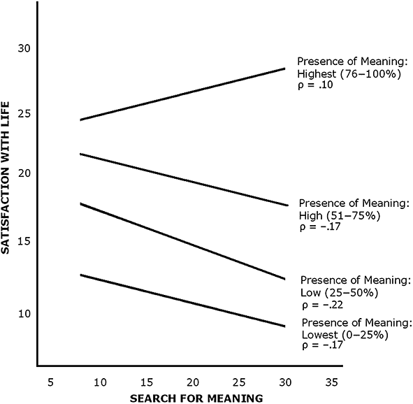

**Figure 1**

Life satisfaction as a function of the search for meaning among respondents differing in the presence of meaning. Partial correlations (ρs) estimate the association between search for meaning and life satisfaction within each quartile of the sample, controlling for age, gender, education, and presence of meaning.

## DISCUSSION

Having a sense of meaning and purpose in life is crucial for health and well-being, and it is both a goal for and a means to a fulfilling life. The present study extends past research by showing in a large US sample that the presence of meaning in life was positively associated with well-being, whereas the search for meaning in general was negatively associated. The additional and major contribution of the present study is showing that the search for meaning was positively associated with well-being—greater life satisfaction, more happiness, and less depression—among those who already had substantial meaning in their lives. So, once meaning in life is present, the search for *further* meaning is linked to well-being (cf. Steger et al., 2008).

When people already have meaning, they have a foundation that allows the search for further meaning to be a process of modification and expansion. In contrast, when people do not have meaning in their life, the search for meaning can be difficult and frustrating. This process requires the creation of a deeper understanding of themselves and the world, a larger perspective about life, and an ongoing effort to extract the significance of ongoing experiences. As a result, life satisfaction during this process can be low. Fine-grained future research into the processes involved in searching for meaning are necessary to test this thesis.

Among those who have meaning in their life, who seeks further meaning? This question is an important one to address in future research. Perhaps these individuals have encountered a particular challenge or disappointment, and draw on their general sense of meaning to cope with what confronts them. Affleck and Tennen (1996) distinguished between *benefit-finding—*making sense of misfortunes—and *benefit-reminding—*using this sense of meaning to cope deliberately with specific incidents. This distinction may be useful in guiding further research into the dynamics of meaning, its presence and search.

One obvious limitation of the present research is the use of an Internet sample. Although increasingly common in psychological research, samples obtained from the Internet may limit generalisability. However, studies by Gosling, Vazire, Srivastava, and John (2004) found that Internet methods were as reliable and valid as more traditional strategies of gathering data, and furthermore that Internet samples were usually more diverse.

Another shortcoming of the present study is its cross-sectional design, which leaves unclear the sequencing of constructs (Steger et al., 2006, 2008). However, some longitudinal studies have shown that having a sense of meaning precedes life satisfaction (e.g. Steger & Kashdan, 2007). If we extrapolate the results of the present investigation, they have implications for the psychological good life and how it might be achieved. Among those with low presence of meaning, the search for meaning per se may be counter-productive, at least in the short run. But among those with high presence of meaning, the search for further meaning may enhance life satisfaction.

Mental health professionals see on a daily basis that meaning matters. People seek treatment not just to solve problems but to live more fully. Clients of course seek help to solve specific problems and to mitigate troubling symptoms, but these goals do not exhaust their motives for treatment (Drieschner, Lammers, & van der Staak, 2004; Zimmerman et al., 2006). Meaning in one's life is an important contributor to fulfillment and therefore is both a target and means to this end (Park & Peterson, 2009). However, given that the search for meaning may produce discomfort, it would be useful to remind clients that the process may be difficult. Furthermore, considering that the attempt to find meaning in traumatic events can lead to poor adjustment (Bonanno et al., 2005), it is important that people not be pressured or hurried to find meaning in the wake of trauma. Perhaps it might be useful as well for therapists and counselors to help their clients find domains in which their life already does have meaning—work, love, or play—and use lessons from these domains as the basis for seeking meaning elsewhere.

Wong (1998b) sketched the basis of meaning-centered counseling, which blends the tenets of Frankl's (1959) logotherapy with cognitive and behavioral techniques. Clients are encouraged to think differently about life's challenges and to place them in the context of larger existential issues. Discomfort—“unhappiness”—is not necessarily negative if it is produced by grappling with what really matters. This information is important for clients to know given research findings that people may rely on the experience of positive affect—feeling good—to judge whether an activity is meaningful (King, Hicks, Krull, & Del Gaiso, 2006).

Meaning-centered counseling, as envisioned by Wong (1998b), also encourages clients to behave differently, to set goals that matter and to cope more effectively with roadblocks along the way. These recommendations converge with those of acceptance and commitment therapy (ACT; Hayes, Strosahl, & Wilson, 1999). ACT instructs clients to accept psychological pain as normal and indeed important but also teaches them how to avoid increasing it unnecessarily. One of the principles of ACT is that too much attention to thinking may exacerbate psychological problems. Perhaps this explains why the search for meaning can be associated with decreased well-being. If all someone does is to *think* about the meaning of life, how different is this from rumination (Nolen-Hoeksema, 2000)?

Perhaps it is better to engage life and abstract from this engagment its meaning. This recommendation is embodied in Frankl's (1975) technique of dereflection (i.e. to divert attention from problems toward meaningful activities in the world); the Alcoholics Anonymous adage to “fake it till you make it” (i.e. to behave as if desired changes have already occurred; cf. Fleeson, Malanos, & Achille, 2002); and strategies of the indigeous Japanese approach of Mortia psychotherapy (i.e. to engage in meaningul work; Reynolds, 1976).

In sum, the present results suggest that the search for meaning is not only morally worthy but as it succeeds, eventually satisfying. For many, the search for meaning is an ongoing quest. The present data may provide some empirical comfort along the way.

## Citing Literature

[Volume2, Issue1](https://iaap-journals.onlinelibrary.wiley.com/toc/17580854/2010/2/1)

March 2010

Pages 1-13

- - Affleck, G., & Tennen, H. (1996). Construing benefits from adversity: Adaptational significance and dispositional underpinnings. Journal of Personality, 64, 899–922.

    [Wiley Online Library](https://iaap-journals.onlinelibrary.wiley.com/doi/10.1111/j.1467-6494.1996.tb00948.x)[CAS](https://iaap-journals.onlinelibrary.wiley.com/servlet/linkout?suffix=null&dbid=32&doi=10.1111%2Fj.1758-0854.2009.01024.x&key=1%3ASTN%3A280%3ADyaK2s7hsVygtA%253D%253D)[PubMed](https://iaap-journals.onlinelibrary.wiley.com/servlet/linkout?suffix=null&dbid=8&doi=10.1111%2Fj.1758-0854.2009.01024.x&key=8956517)[Web of Science®](https://iaap-journals.onlinelibrary.wiley.com/servlet/linkout?suffix=null&dbid=128&doi=10.1111%2Fj.1758-0854.2009.01024.x&key=A1996VV80700007)Google Scholar
  - Antonovsky, A. (1979). Health, stress, and coping. San Francisco, CA: Jossey-Bass.

    [Google Scholar](http://scholar.google.com/scholar_lookup?hl=en&publication_year=1979&author=A.+Antonovsky&title=Health%2C+stress%2C+and+coping)
  - Battista, J., & Almond, R. (1973). The development of meaning in life. Psychiatry, 36, 409–427.

    [Crossref](https://iaap-journals.onlinelibrary.wiley.com/servlet/linkout?suffix=null&dbid=16&doi=10.1111%2Fj.1758-0854.2009.01024.x&key=10.1080%2F00332747.1973.11023774)[CAS](https://iaap-journals.onlinelibrary.wiley.com/servlet/linkout?suffix=null&dbid=32&doi=10.1111%2Fj.1758-0854.2009.01024.x&key=1%3ASTN%3A280%3ADyaE2c%252FktVGrug%253D%253D)[PubMed](https://iaap-journals.onlinelibrary.wiley.com/servlet/linkout?suffix=null&dbid=8&doi=10.1111%2Fj.1758-0854.2009.01024.x&key=4756415)[Web of Science®](https://iaap-journals.onlinelibrary.wiley.com/servlet/linkout?suffix=null&dbid=128&doi=10.1111%2Fj.1758-0854.2009.01024.x&key=A1973R491700005)[Google Scholar](http://scholar.google.com/scholar_lookup?hl=en&volume=36&publication_year=1973&pages=409-427&journal=Psychiatry&author=J.+Battista&author=R.+Almond&title=The+development+of+meaning+in+life)
  - Baumeister, R.F., & Vohs, K.D. (2002). The pursuit of meaningfulness in life. In C.R. Snyder & S.J. Lopez (Eds.), Handbook of positive psychology (pp. 608–618). New York: Oxford University Press.

    [Google Scholar](http://scholar.google.com/scholar_lookup?hl=en&publication_year=2002&pages=608-618&author=R.F.+Baumeister&author=K.D.+Vohs&title=Handbook+of+positive+psychology)
  - Bonanno, G.A., Papa, A., & Lalande, K. (2005). Grief processing and deliberate grief avoidance: A prospective comparison of bereaved spouses and parents in the United States and the People's Republic of China. Journal of Consulting and Clinical Psychology, 73, 86–98.

    [Crossref](https://iaap-journals.onlinelibrary.wiley.com/servlet/linkout?suffix=null&dbid=16&doi=10.1111%2Fj.1758-0854.2009.01024.x&key=10.1037%2F0022-006X.73.1.86)[PubMed](https://iaap-journals.onlinelibrary.wiley.com/servlet/linkout?suffix=null&dbid=8&doi=10.1111%2Fj.1758-0854.2009.01024.x&key=15709835)[Web of Science®](https://iaap-journals.onlinelibrary.wiley.com/servlet/linkout?suffix=null&dbid=128&doi=10.1111%2Fj.1758-0854.2009.01024.x&key=000227000400010)Google Scholar
  - Boyle, P.A., Barnes, L.L., Buchman, A.S., & Bennett, D.A. (2009). Purpose in life is associated with mortality among community-dwelling older persons. Psychosomatic Medicine, 71, 574–579.

    [Crossref](https://iaap-journals.onlinelibrary.wiley.com/servlet/linkout?suffix=null&dbid=16&doi=10.1111%2Fj.1758-0854.2009.01024.x&key=10.1097%2FPSY.0b013e3181a5a7c0)[PubMed](https://iaap-journals.onlinelibrary.wiley.com/servlet/linkout?suffix=null&dbid=8&doi=10.1111%2Fj.1758-0854.2009.01024.x&key=19414613)[Web of Science®](https://iaap-journals.onlinelibrary.wiley.com/servlet/linkout?suffix=null&dbid=128&doi=10.1111%2Fj.1758-0854.2009.01024.x&key=000267148200013)Google Scholar
  - Bruner, J.S. (1990). Acts of meaning. Cambridge, MA: Harvard University Press.

    [Google Scholar](http://scholar.google.com/scholar_lookup?hl=en&publication_year=1990&author=J.S.+Bruner&title=Acts+of+meaning)
  - Compton, W.C., Smith, M.L., Cornish, K.A., & Qualls, D.L. (1996). Factor structure of mental health measures. Journal of Personality and Social Psychology, 71, 406–413.

    [Crossref](https://iaap-journals.onlinelibrary.wiley.com/servlet/linkout?suffix=null&dbid=16&doi=10.1111%2Fj.1758-0854.2009.01024.x&key=10.1037%2F0022-3514.71.2.406)[CAS](https://iaap-journals.onlinelibrary.wiley.com/servlet/linkout?suffix=null&dbid=32&doi=10.1111%2Fj.1758-0854.2009.01024.x&key=1%3ASTN%3A280%3ADyaK28zksleqtw%253D%253D)[PubMed](https://iaap-journals.onlinelibrary.wiley.com/servlet/linkout?suffix=null&dbid=8&doi=10.1111%2Fj.1758-0854.2009.01024.x&key=8765489)[Web of Science®](https://iaap-journals.onlinelibrary.wiley.com/servlet/linkout?suffix=null&dbid=128&doi=10.1111%2Fj.1758-0854.2009.01024.x&key=A1996VC18100016)Google Scholar
  - Damon, W., Menon, J., & Bronk, K.C. (2003). The development of purpose during adolescence. Applied Developmental Science, 7, 119–128.

    [Crossref](https://iaap-journals.onlinelibrary.wiley.com/servlet/linkout?suffix=null&dbid=16&doi=10.1111%2Fj.1758-0854.2009.01024.x&key=10.1207%2FS1532480XADS0703_2)Google Scholar
  - Diener, E., Emmons, R.A., Larsen, R.J., & Griffin, S. (1985). The Satisfaction with Life Scale. Journal of Personality Assessment, 49, 71–75.

    [Crossref](https://iaap-journals.onlinelibrary.wiley.com/servlet/linkout?suffix=null&dbid=16&doi=10.1111%2Fj.1758-0854.2009.01024.x&key=10.1207%2Fs15327752jpa4901_13)[CAS](https://iaap-journals.onlinelibrary.wiley.com/servlet/linkout?suffix=null&dbid=32&doi=10.1111%2Fj.1758-0854.2009.01024.x&key=1%3ASTN%3A280%3ADC%252BD2MnotFamuw%253D%253D)[PubMed](https://iaap-journals.onlinelibrary.wiley.com/servlet/linkout?suffix=null&dbid=8&doi=10.1111%2Fj.1758-0854.2009.01024.x&key=16367493)[Web of Science®](https://iaap-journals.onlinelibrary.wiley.com/servlet/linkout?suffix=null&dbid=128&doi=10.1111%2Fj.1758-0854.2009.01024.x&key=A1985AEV0700014)Google Scholar
  - Drieschner, K.H., Lammers, S.M.M., & Van Der Staak, C.P.F. (2004). Treatment motivation: An attempt for clarification of an ambiguous concept. Clinical Psychology Review, 23, 1115–1137.

    [Crossref](https://iaap-journals.onlinelibrary.wiley.com/servlet/linkout?suffix=null&dbid=16&doi=10.1111%2Fj.1758-0854.2009.01024.x&key=10.1016%2Fj.cpr.2003.09.003)[PubMed](https://iaap-journals.onlinelibrary.wiley.com/servlet/linkout?suffix=null&dbid=8&doi=10.1111%2Fj.1758-0854.2009.01024.x&key=14729425)[Web of Science®](https://iaap-journals.onlinelibrary.wiley.com/servlet/linkout?suffix=null&dbid=128&doi=10.1111%2Fj.1758-0854.2009.01024.x&key=000188607200005)Google Scholar
  - Emmons, R.A. (1986). Personal strivings: An approach to personality and subjective well-being. Journal of Personality and Social Psychology, 51, 1058–1068.

    [Crossref](https://iaap-journals.onlinelibrary.wiley.com/servlet/linkout?suffix=null&dbid=16&doi=10.1111%2Fj.1758-0854.2009.01024.x&key=10.1037%2F0022-3514.51.5.1058)[Web of Science®](https://iaap-journals.onlinelibrary.wiley.com/servlet/linkout?suffix=null&dbid=128&doi=10.1111%2Fj.1758-0854.2009.01024.x&key=A1986E738800016)Google Scholar
  - Fleeson, W., Malanos, A., & Achille, N. (2002). An intra-individual, process approach to the relationship between extraversion and positive affect: Is acting extraverted as “good” as being extraverted? Journal of Personality and Social Psychology, 83, 1409–1422.

    [Crossref](https://iaap-journals.onlinelibrary.wiley.com/servlet/linkout?suffix=null&dbid=16&doi=10.1111%2Fj.1758-0854.2009.01024.x&key=10.1037%2F0022-3514.83.6.1409)[PubMed](https://iaap-journals.onlinelibrary.wiley.com/servlet/linkout?suffix=null&dbid=8&doi=10.1111%2Fj.1758-0854.2009.01024.x&key=12500821)[Web of Science®](https://iaap-journals.onlinelibrary.wiley.com/servlet/linkout?suffix=null&dbid=128&doi=10.1111%2Fj.1758-0854.2009.01024.x&key=000179661800012)Google Scholar
  - Frankl, V.E. (1959). Man's search for meaning: An introduction to logotherapy. Boston, MA: Beacon.

    [Google Scholar](http://scholar.google.com/scholar_lookup?hl=en&publication_year=1959&author=V.E.+Frankl&title=Man%27s+search+for+meaning%3A+An+introduction+to+logotherapy)
  - Frankl, V.E. (1965). The doctor and the soul: From psychotherapy to logotherapy. New York: Vintage Books.

    [Google Scholar](http://scholar.google.com/scholar_lookup?hl=en&publication_year=1965&author=V.E.+Frankl&title=The+doctor+and+the+soul%3A+From+psychotherapy+to+logotherapy)
  - Frankl, V.E. (1975). Paradoxical intention and dereflection. Psychotherapy: Theory, Research, and Practice, 12, 226–237.

    [Crossref](https://iaap-journals.onlinelibrary.wiley.com/servlet/linkout?suffix=null&dbid=16&doi=10.1111%2Fj.1758-0854.2009.01024.x&key=10.1037%2Fh0086434)[Web of Science®](https://iaap-journals.onlinelibrary.wiley.com/servlet/linkout?suffix=null&dbid=128&doi=10.1111%2Fj.1758-0854.2009.01024.x&key=A1975BT87500001)Google Scholar
  - Freud, S. (1961). The future of an illusion. New York: Norton (originally published 1927).

    [Google Scholar](http://scholar.google.com/scholar_lookup?hl=en&publication_year=1961&author=S.+Freud&title=The+future+of+an+illusion)
  - Gosling, S.D., Vazire, S., Srivastava, S., & John, O.P. (2004). Should we trust Web-based studies? A comparative analysis of six preconceptions about Internet questionnaires. American Psychologist, 59, 93–104.

    [Crossref](https://iaap-journals.onlinelibrary.wiley.com/servlet/linkout?suffix=null&dbid=16&doi=10.1111%2Fj.1758-0854.2009.01024.x&key=10.1037%2F0003-066X.59.2.93)[PubMed](https://iaap-journals.onlinelibrary.wiley.com/servlet/linkout?suffix=null&dbid=8&doi=10.1111%2Fj.1758-0854.2009.01024.x&key=14992636)[Web of Science®](https://iaap-journals.onlinelibrary.wiley.com/servlet/linkout?suffix=null&dbid=128&doi=10.1111%2Fj.1758-0854.2009.01024.x&key=000189249800002)Google Scholar
  - Hayes, S.C., Strosahl, K.D., & Wilson, K.G. (1999). Acceptance and commitment therapy: An experiential approach to behavior change. New York: Guilford.

    Google Scholar
  - King, L., Hicks, J.A., Krull, J.L., & Del Gaiso, A. (2006). Positive affect and the experience of meaning in life. Journal of Personality and Social Psychology, 90, 179–196.

    [Crossref](https://iaap-journals.onlinelibrary.wiley.com/servlet/linkout?suffix=null&dbid=16&doi=10.1111%2Fj.1758-0854.2009.01024.x&key=10.1037%2F0022-3514.90.1.179)[PubMed](https://iaap-journals.onlinelibrary.wiley.com/servlet/linkout?suffix=null&dbid=8&doi=10.1111%2Fj.1758-0854.2009.01024.x&key=16448317)[Web of Science®](https://iaap-journals.onlinelibrary.wiley.com/servlet/linkout?suffix=null&dbid=128&doi=10.1111%2Fj.1758-0854.2009.01024.x&key=000235112100011)Google Scholar
  - Klinger, E. (1977). Meaning and void: Inner experience and the incentives in people's lives. Minneapolis, MN: University of Minnesota Press.

    [Google Scholar](http://scholar.google.com/scholar_lookup?hl=en&publication_year=1977&author=E.+Klinger&title=Meaning+and+void%3A+Inner+experience+and+the+incentives+in+people%27s+lives)
  - Maddi, S.R. (1970). The search for meaning. In M. Page (Ed.), Nebraska Symposium on Motivation (pp. 137–186). Lincoln, NE: University of Nebraska Press.

    [Google Scholar](http://scholar.google.com/scholar_lookup?hl=en&publication_year=1970&pages=137-186&author=S.R.+Maddi&title=Nebraska+Symposium+on+Motivation)
  - Maslow, A.H. (1954). Motivation and personality. New York: Harper & Row.

    [Web of Science®](https://iaap-journals.onlinelibrary.wiley.com/servlet/linkout?suffix=null&dbid=128&doi=10.1111%2Fj.1758-0854.2009.01024.x&key=A1954UH15300005)[Google Scholar](http://scholar.google.com/scholar_lookup?hl=en&publication_year=1954&author=A.H.+Maslow&title=Motivation+and+personality)
  - May, R. (1953). Man's search for himself. New York: Norton.

    [Google Scholar](http://scholar.google.com/scholar_lookup?hl=en&publication_year=1953&author=R.+May&title=Man%27s+search+for+himself)
  - Newcomb, M.D., & Harlow, L.L. (1986). Life events and substance use among adolescents: Mediating effects of perceived loss of control and meaninglessness in life. Journal of Personality and Social Psychology, 51, 564–577.

    [Crossref](https://iaap-journals.onlinelibrary.wiley.com/servlet/linkout?suffix=null&dbid=16&doi=10.1111%2Fj.1758-0854.2009.01024.x&key=10.1037%2F0022-3514.51.3.564)[PubMed](https://iaap-journals.onlinelibrary.wiley.com/servlet/linkout?suffix=null&dbid=8&doi=10.1111%2Fj.1758-0854.2009.01024.x&key=3489832)[Web of Science®](https://iaap-journals.onlinelibrary.wiley.com/servlet/linkout?suffix=null&dbid=128&doi=10.1111%2Fj.1758-0854.2009.01024.x&key=A1986D847600009)Google Scholar
  - Nolen-Hoeksema, S. (2000). The role of rumination in depressive disorders and mixed anxiety/depressive symptoms. Journal of Abnormal Psychology, 109, 504–511.

    [Crossref](https://iaap-journals.onlinelibrary.wiley.com/servlet/linkout?suffix=null&dbid=16&doi=10.1111%2Fj.1758-0854.2009.01024.x&key=10.1037%2F0021-843X.109.3.504)[CAS](https://iaap-journals.onlinelibrary.wiley.com/servlet/linkout?suffix=null&dbid=32&doi=10.1111%2Fj.1758-0854.2009.01024.x&key=1%3ASTN%3A280%3ADC%252BD3cvmsVamsQ%253D%253D)[PubMed](https://iaap-journals.onlinelibrary.wiley.com/servlet/linkout?suffix=null&dbid=8&doi=10.1111%2Fj.1758-0854.2009.01024.x&key=11016119)[Web of Science®](https://iaap-journals.onlinelibrary.wiley.com/servlet/linkout?suffix=null&dbid=128&doi=10.1111%2Fj.1758-0854.2009.01024.x&key=000089411800015)Google Scholar
  - Park, N., & Peterson, C. (2009). Achieving and sustaining a good life. Perspectives on Psychological Science, 4, 422–428.

    [Crossref](https://iaap-journals.onlinelibrary.wiley.com/servlet/linkout?suffix=null&dbid=16&doi=10.1111%2Fj.1758-0854.2009.01024.x&key=10.1111%2Fj.1745-6924.2009.01149.x)[Web of Science®](https://iaap-journals.onlinelibrary.wiley.com/servlet/linkout?suffix=null&dbid=128&doi=10.1111%2Fj.1758-0854.2009.01024.x&key=000267755400017)Google Scholar
  - Peterson, C. (2006). A primer in positive psychology. New York: Oxford University Press.

    [Google Scholar](http://scholar.google.com/scholar_lookup?hl=en&publication_year=2006&author=C.+Peterson&title=A+primer+in+positive+psychology)
  - Peterson, C., & Park, N. (2008). The Authentic Happiness Inventory. Unpublished manuscript, University of Michigan.

    [Google Scholar](http://scholar.google.com/scholar?hl=en&q=%0APeterson%2C+C.%2C+%26+Park%2C+N.+%282008%29.+The+Authentic+Happiness+Inventory.+Unpublished+manuscript%2C+University+of+Michigan.%0A)
  - Peterson, C., Park, N., & Seligman, M.E.P. (2005). Orientations to happiness and life satisfaction: The full life versus the empty life. Journal of Happiness Studies, 6, 25–41.

    [Crossref](https://iaap-journals.onlinelibrary.wiley.com/servlet/linkout?suffix=null&dbid=16&doi=10.1111%2Fj.1758-0854.2009.01024.x&key=10.1007%2Fs10902-004-1278-z)[PubMed](https://iaap-journals.onlinelibrary.wiley.com/servlet/linkout?suffix=null&dbid=8&doi=10.1111%2Fj.1758-0854.2009.01024.x&key=1029044)Google Scholar
  - Peterson, C., Ruch, W., Beermann, U., Park, N., & Seligman, M.E.P. (2007). Strengths of character, orientations to happiness, and life satisfaction. Journal of Positive Psychology, 2, 149–156.

    [Crossref](https://iaap-journals.onlinelibrary.wiley.com/servlet/linkout?suffix=null&dbid=16&doi=10.1111%2Fj.1758-0854.2009.01024.x&key=10.1080%2F17439760701228938)Google Scholar
  - Radloff, L.S. (1977). The CES-D Scale: A self-report depression scale for research in the general population. Applied Psychological Measurement, 1, 385–401.

    [Crossref](https://iaap-journals.onlinelibrary.wiley.com/servlet/linkout?suffix=null&dbid=16&doi=10.1111%2Fj.1758-0854.2009.01024.x&key=10.1177%2F014662167700100306)[PubMed](https://iaap-journals.onlinelibrary.wiley.com/servlet/linkout?suffix=null&dbid=8&doi=10.1111%2Fj.1758-0854.2009.01024.x&key=16221013)[Web of Science®](https://iaap-journals.onlinelibrary.wiley.com/servlet/linkout?suffix=null&dbid=128&doi=10.1111%2Fj.1758-0854.2009.01024.x&key=000232548500013)Google Scholar
  - Reynolds, D.K. (1976). Morita psychotherapy. Berkeley, CA: University of California Press.

    [Google Scholar](http://scholar.google.com/scholar_lookup?hl=en&publication_year=1976&author=D.K.+Reynolds&title=Morita+psychotherapy)
  - Rogers, C.R. (1961). On becoming a person. Boston, MA: Houghton Mifflin.

    [Google Scholar](http://scholar.google.com/scholar_lookup?hl=en&publication_year=1961&author=C.R.+Rogers&title=On+becoming+a+person)
  - Ryan, R.M., & Deci, E.L. (2001). On happiness and human potentials: A review of research on hedonic and eudaimonic well-being. Annual Review of Psychology, 52, 141–166.

    [Crossref](https://iaap-journals.onlinelibrary.wiley.com/servlet/linkout?suffix=null&dbid=16&doi=10.1111%2Fj.1758-0854.2009.01024.x&key=10.1146%2Fannurev.psych.52.1.141)[CAS](https://iaap-journals.onlinelibrary.wiley.com/servlet/linkout?suffix=null&dbid=32&doi=10.1111%2Fj.1758-0854.2009.01024.x&key=1%3ASTN%3A280%3ADC%252BD3Mzptlaktg%253D%253D)[PubMed](https://iaap-journals.onlinelibrary.wiley.com/servlet/linkout?suffix=null&dbid=8&doi=10.1111%2Fj.1758-0854.2009.01024.x&key=11148302)[Web of Science®](https://iaap-journals.onlinelibrary.wiley.com/servlet/linkout?suffix=null&dbid=128&doi=10.1111%2Fj.1758-0854.2009.01024.x&key=000167463100008)Google Scholar
  - Ryff, C.D., & Singer, B.H. (1998). The contours of positive mental health. Psychological Inquiry, 9, 1–28.

    [Crossref](https://iaap-journals.onlinelibrary.wiley.com/servlet/linkout?suffix=null&dbid=16&doi=10.1111%2Fj.1758-0854.2009.01024.x&key=10.1207%2Fs15327965pli0901_1)[Web of Science®](https://iaap-journals.onlinelibrary.wiley.com/servlet/linkout?suffix=null&dbid=128&doi=10.1111%2Fj.1758-0854.2009.01024.x&key=000072139000001)[Google Scholar](http://scholar.google.com/scholar_lookup?hl=en&volume=9&publication_year=1998&pages=1-28&journal=Psychological+Inquiry&author=C.D.+Ryff&author=B.H.+Singer&title=The+contours+of+positive+mental+health)
  - Seligman, M.E.P. (2002). Authentic happiness. New York: Free Press.

    [Google Scholar](http://scholar.google.com/scholar_lookup?hl=en&publication_year=2002&author=M.E.P.+Seligman&title=Authentic+happiness)
  - Skinner, B.F. (1971). Beyond freedom and dignity. New York: Knopf.

    [Google Scholar](http://scholar.google.com/scholar_lookup?hl=en&publication_year=1971&author=B.F.+Skinner&title=Beyond+freedom+and+dignity)
  - Sone, T., Nakaya, N., Ohmori, K., Shimazu, T., Higashiguchi, M., Kakizaki, M. *et al.* (2008). Sense of life worth living (ikigai) and mortality in Japan: Ohsaki Study. Psychosomatic Medicine, 70, 709–715.

    [Crossref](https://iaap-journals.onlinelibrary.wiley.com/servlet/linkout?suffix=null&dbid=16&doi=10.1111%2Fj.1758-0854.2009.01024.x&key=10.1097%2FPSY.0b013e31817e7e64)[PubMed](https://iaap-journals.onlinelibrary.wiley.com/servlet/linkout?suffix=null&dbid=8&doi=10.1111%2Fj.1758-0854.2009.01024.x&key=18596247)[Web of Science®](https://iaap-journals.onlinelibrary.wiley.com/servlet/linkout?suffix=null&dbid=128&doi=10.1111%2Fj.1758-0854.2009.01024.x&key=000257827100012)Google Scholar
  - Steger, M.F., Frazier, P., & Oishi, S. (2006). The Meaning in Life Questionnaire: Assessing the presence of and search for meaning in life. Journal of Counseling Psychology, 53, 80–93.

    [Crossref](https://iaap-journals.onlinelibrary.wiley.com/servlet/linkout?suffix=null&dbid=16&doi=10.1111%2Fj.1758-0854.2009.01024.x&key=10.1037%2F0022-0167.53.1.80)[Web of Science®](https://iaap-journals.onlinelibrary.wiley.com/servlet/linkout?suffix=null&dbid=128&doi=10.1111%2Fj.1758-0854.2009.01024.x&key=000234583100008)Google Scholar
  - Steger, M.F., & Kashdan, T.B. (2007). Stability and specificity of meaning in life and life satisfaction over one year: Implications for outcome assessment. Journal of Happiness Studies, 8, 161–179.

    [Crossref](https://iaap-journals.onlinelibrary.wiley.com/servlet/linkout?suffix=null&dbid=16&doi=10.1111%2Fj.1758-0854.2009.01024.x&key=10.1007%2Fs10902-006-9011-8)Google Scholar
  - Steger, M.F., Kashdan, T.B., Sullivan, B.A., & Lorentz, D. (2008). Understanding the search for meaning in life: Personality, cognitive style, and the dynamic between seeking and experiencing meaning. Journal of Personality, 76, 199–228.

    [Wiley Online Library](https://iaap-journals.onlinelibrary.wiley.com/doi/10.1111/j.1467-6494.2007.00484.x)[PubMed](https://iaap-journals.onlinelibrary.wiley.com/servlet/linkout?suffix=null&dbid=8&doi=10.1111%2Fj.1758-0854.2009.01024.x&key=18331281)[Web of Science®](https://iaap-journals.onlinelibrary.wiley.com/servlet/linkout?suffix=null&dbid=128&doi=10.1111%2Fj.1758-0854.2009.01024.x&key=000254415400002)Google Scholar
  - Steger, M.F., Oishi, S., & Kashdan, T.B. (2009). Meaning in life across the life span: Levels and correlates of meaning in life from emerging adulthood to older adulthood. Journal of Positive Psychology, 4, 43–52.

    [Crossref](https://iaap-journals.onlinelibrary.wiley.com/servlet/linkout?suffix=null&dbid=16&doi=10.1111%2Fj.1758-0854.2009.01024.x&key=10.1080%2F17439760802303127)[Web of Science®](https://iaap-journals.onlinelibrary.wiley.com/servlet/linkout?suffix=null&dbid=128&doi=10.1111%2Fj.1758-0854.2009.01024.x&key=000207953100005)Google Scholar
  - Thompson, S.C., & Janigian, A.S. (1988). Life schemes: A framework for understanding the search for meaning. Journal of Social and Clinical Psychology, 7, 260–280.

    [Crossref](https://iaap-journals.onlinelibrary.wiley.com/servlet/linkout?suffix=null&dbid=16&doi=10.1111%2Fj.1758-0854.2009.01024.x&key=10.1521%2Fjscp.1988.7.2-3.260)[Web of Science®](https://iaap-journals.onlinelibrary.wiley.com/servlet/linkout?suffix=null&dbid=128&doi=10.1111%2Fj.1758-0854.2009.01024.x&key=A1988R205800015)Google Scholar
  - Waterman, A.S. (1993). Two conceptions of happiness: Contrasts of personal expressiveness (eudaimonia) and hedonic enjoyment. Journal of Personality and Social Psychology, 64, 678–691.

    [Crossref](https://iaap-journals.onlinelibrary.wiley.com/servlet/linkout?suffix=null&dbid=16&doi=10.1111%2Fj.1758-0854.2009.01024.x&key=10.1037%2F0022-3514.64.4.678)[Web of Science®](https://iaap-journals.onlinelibrary.wiley.com/servlet/linkout?suffix=null&dbid=128&doi=10.1111%2Fj.1758-0854.2009.01024.x&key=A1993KV36700014)Google Scholar
  - Watson, D., Clark, L.A., & Tellegen, A. (1988). Development and validation of brief measures of positive and negative affect: The PANAS scales. Journal of Personality and Social Psychology, 54, 1063–1070.

    [Crossref](https://iaap-journals.onlinelibrary.wiley.com/servlet/linkout?suffix=null&dbid=16&doi=10.1111%2Fj.1758-0854.2009.01024.x&key=10.1037%2F0022-3514.54.6.1063)[CAS](https://iaap-journals.onlinelibrary.wiley.com/servlet/linkout?suffix=null&dbid=32&doi=10.1111%2Fj.1758-0854.2009.01024.x&key=1%3ASTN%3A280%3ADyaL1c3os1ersA%253D%253D)[PubMed](https://iaap-journals.onlinelibrary.wiley.com/servlet/linkout?suffix=null&dbid=8&doi=10.1111%2Fj.1758-0854.2009.01024.x&key=3397865)[Web of Science®](https://iaap-journals.onlinelibrary.wiley.com/servlet/linkout?suffix=null&dbid=128&doi=10.1111%2Fj.1758-0854.2009.01024.x&key=A1988N666500016)Google Scholar
  - Weinstein, L., & Cleanthous, C.C. (1996). A comparison of Protestant ministers and parishioners on expressed purpose in life and intrinsic religious motivation. Psychology: A Journal of Human Behavior, 33, 26–29.

    [Web of Science®](https://iaap-journals.onlinelibrary.wiley.com/servlet/linkout?suffix=null&dbid=128&doi=10.1111%2Fj.1758-0854.2009.01024.x&key=A1996UN93900005)Google Scholar
  - Wong, P.T.P. (1998a). Implicit theories of meaningful life and the development of the Personal Meaning Profile. In P.T.P. Wong & P.S. Fry (Eds.), The human quest for meaning: A handbook of psychological research and clinical applications (pp. 111–140). Mahwah, NJ: Erlbaum.

    [Google Scholar](http://scholar.google.com/scholar_lookup?hl=en&publication_year=1998a&pages=111-140&author=P.T.P.+Wong&title=The+human+quest+for+meaning%3A+A+handbook+of+psychological+research+and+clinical+applications)
  - Wong, P.T.P. (1998b). Meaning-centered counseling. In P.T.P. Wong & P.S. Fry (Eds.), The human quest for meaning: A handbook of psychological research and clinical applications (pp. 393–435). Mahwah, NJ: Erlbaum.

    [Web of Science®](https://iaap-journals.onlinelibrary.wiley.com/servlet/linkout?suffix=null&dbid=128&doi=10.1111%2Fj.1758-0854.2009.01024.x&key=000077191600009)[Google Scholar](http://scholar.google.com/scholar_lookup?hl=en&publication_year=1998b&pages=393-435&author=P.T.P.+Wong&title=The+human+quest+for+meaning%3A+A+handbook+of+psychological+research+and+clinical+applications)
  - Zika, S., & Chamberlain, K. (1987). Relation of hassles and personality to subjective well-being. Journal of Personality and Social Psychology, 53,155–162.

    [Crossref](https://iaap-journals.onlinelibrary.wiley.com/servlet/linkout?suffix=null&dbid=16&doi=10.1111%2Fj.1758-0854.2009.01024.x&key=10.1037%2F0022-3514.53.1.155)[Web of Science®](https://iaap-journals.onlinelibrary.wiley.com/servlet/linkout?suffix=null&dbid=128&doi=10.1111%2Fj.1758-0854.2009.01024.x&key=A1987H936600016)Google Scholar
  - Zimmerman, M., McGlinchey, J.B., Posternak, M.A., Friedman, M., Attiullah, N., & Boerescu, D. (2006). How should remission from depression be defined? The depressed patient's perspective. American Journal of Psychiatry, 163, 148–150.

    [Crossref](https://iaap-journals.onlinelibrary.wiley.com/servlet/linkout?suffix=null&dbid=16&doi=10.1111%2Fj.1758-0854.2009.01024.x&key=10.1176%2Fappi.ajp.163.1.148)[PubMed](https://iaap-journals.onlinelibrary.wiley.com/servlet/linkout?suffix=null&dbid=8&doi=10.1111%2Fj.1758-0854.2009.01024.x&key=16390903)[Web of Science®](https://iaap-journals.onlinelibrary.wiley.com/servlet/linkout?suffix=null&dbid=128&doi=10.1111%2Fj.1758-0854.2009.01024.x&key=000234367100027)Google Scholar